# MOHAMMED SHOEBUDDIN HABEEB, mhabeeb2@student.gsu.edu and 002521737

## Question 1 [5 Pts]

What is Unsupervised Learning and difficulties involved in unsupervied Learning and name a few unsupervised algorithms ?

### Solution

Unsupervised learning infers patterns from a dataset without reference to known outcomes. Unsupervised learning can be used to uncover previously unknown pattern in data, however, these patterns may be poor estimates as compared to what supervised learning can achieve.

Difficulties involved in unsupervised learning – It is not possible to fit a linear regression model, since there is no associated response variable to predict. Unsupervised learning is usually performed as part of exploratory data analysis. Assessing results obtained from unsupervised learning can be difficult, since there is no common mechanism to perform validation on individual data sets.

Unsupervised Learning algorithms – K-Means Clustering, Hierarchical clustering, Neural Networks, Gaussian Mixture, Hidden Markov Model.

## Question 2 [5 Pts]

What is a PCA [Principal Component Analysis] and When to use PCA [Principal Component Analysis] ?

### Solution

PCA is Principle Components Analysis. PCA refers to the process of computing principal components, and usage of these components for understanding the data. PCA is an unsupervised learning method as it involves only set of features say X1, X2, . . . , Xp, and no associated response Y.

PCA can also be used as a tool for visualizing data i.e. visualizing the observations and visualizing the variables. PCA provides a way to visualize high dimensional data providing the most important information.

For example, PCA is predominantly used as dimension reduction technique. Domains like facial recognition, image compression and computer vision. PCA can also be used in finding data patterns in high dimensional data of finance, data mining, bioinformatics etc.

## Question 3 [5 Pts]

How does a PCA work [Principal Component Analysis] ?

### Solution

Steps of working of PCA – a. Calculate the covariance matrix X of data points. b. Calculate the eigen vectors and corresponding eigen values. c. Sort the eigen vectors according to their eigen values in decreasing order. d. Choose first k eigen vectors which will be the new k dimensions. e. Transform the original n dimensional data points into k dimensions.

## Question 4 [5 Pts]

What are different methods by which you can compute the PCA? Does every method will yield same result or answer at the end?

### Solution

PCA can be computed by calculating covariance and calculating eigen vectors and it's corresponding eigen values. On sorting the eigen values in decreasing order, we can choose first 'k' eigen vectors to transform the original data points to a k-dimension plot. It depends on the number of k dimensions we select for plotting PCA which yields different results at the end. We need to know the most approc=ximate k-value which would help us analyse the data set better.

## Question 5 [5 Pts]

What are advantages and disadvantages of PCA[Explain with example]?

### Solution

Advantages-

i. Removes correlated features. For example, in real world scenarios with data set having thousands of features, algorithm cannot be run on all the features which in turn reduces the performance of the algorithm. Finding correlation among features and reducing the number of features helps in running the algorithms faster. Hence, on implementing PCA on the data set, all the Principal components are independent of one another and there is no correlation among them. ii. Improves algorithm performance iii. Reduces Overfitting iv. Improves Visualization

Disadvantages –

i. Independent variables become less interpretable. ii. Data standardization is a must before PCA. iii. Information loss

## Question 6 [10 Pts]

What is clustering? Explain how K-Means Clustering Algorithm works?

### Solution

Clustering in data mining is an unsupervised learning procedure whose goal is to find homogenous subgroups among the observations. A cluster of data objects can be considered as one group. Advantage of clustering over classification is that it is adaptable to changes and helps group useful features that distinguish different groups.

Clustering analysis is used in applications such as market research, pattern recognition, image processing and data analysis. As a data mining function, clustering serves as a tool to gain insight into distribution of data to observe characteristics of each cluster.

Working of K-means clustering:-

The K-means clustering algorithm halts creating and optimizing clusters when either – a. The centroids have stabilized i.e. no change in centroids values because the clustering is successful, or, b. The defined number of iterations is achieved. K-means clustering can be achieved programmatically using python’s Scikit-learn library.

## Question 7 [10 Pts]

What are the Advantages and disadvantages of Clustering ALgorithms discussed in our class (K-Means,Hierchal)?

### Solution

K-Means Advantages & Disadvantages: Advantages- i. Easy to implement. ii. With large number of variables, K-Means may be computationally faster than hierarchical clustering, if k is small. iii. K-Means may produce tighter clusters than hierarchical clustering. iv. An instance can change cluster when the centroids are recomputed. Disadvantages – i. Difficult to predict the number of clusters i.e. the k value. ii. Initial seeds have strong impact on results. iii. Order of the data has impact on the final results. iv. Rescaling the datasets by normalization or standardization completely changes the results.

Hierarchical clustering Advantages & Disadvantages: Advantages- i. Hierarchical clustering outputs a hierarchy, i.e. structure that is more informative than unstructured set of clusters returned by k-means. Hence, it is easy to decide the number of clusters by looking at the dendrogram. ii. Easy to implement.

Disadvantages- i. It is not possible to undo a step already executed, i.e. once the instances have been assigned to a cluster, it can not be moved to another cluster. ii. Time complexity: It is not suitable for huge datasets. iii. Very sensitive to outliers.

## Question 8 [5 Pts]

Which Clustering Algorithm is better K-Means or hierarchical Clustering? Explain with a proper example which is better algorithm?

### Solution

According to me hierarchical clustering is better compared to K-Means clustering. Hierarchical clustering is more flexible and has fewer assumptions about the distribution of dataset.

K-Means clustering requires a sense ahead-of-time about the desired number of clusters i.e. k-value. Also, K-Means gives unintuitive results if the data is not well-separated into clusters. Results may vary if the k-value selected is not well suited to the shape of the data, i.e. k-value picked is too high or too low. Different initial values for centroids may result in different cluster groupings.

In contrast, Hierarchical clustering has fewer assumptions about the distribution of data. Distance between each pair of data points such as Euclidian distance needs to be calculated. Hierarchical clustering joins nearby points into a cluster and then successively adds nearest points to the nearest group. The output of the algorithm is a dendrogram. Interpretation from the dendrograms requires special attention. The distance between two clusters is the maximum distance between any pair of samples, one in each cluster.

## Question 9 & 10 [ 50 Pts]

Please Perform Principal Component Analysis and K-Means Clustering on the Give dataset Below.

10 Points for Data Preprocessing.

15 Points for PCA Algorithm along with plots and Results Explaination.

15 Points for K-Means Algorithm with plots and Results Explination.

10 Points for Comparing the results between PCA and K-Means and whats your inference from your ouputs of the algorithms.

Hints:

1. As per the data preprocessing step convert all the variables in the dataset into Numerical values as the algorithms only work with Numerical values
2. Then Apply both algorithms one after the other then plot the ouput clusters
3. Compare the output clusters in both the steps.

## Bank Marketing Data Set

URL: https://dataminingcsc6740.s3-us-west-2.amazonaws.com/datasets/homework_2.csv

### Files Information:

the homework_2.csv has all the informatiom.

### Relevant Information:

The data is related with direct marketing campaigns of a Portuguese banking institution. The marketing campaigns were based on phone calls. Often, more than one contact to the same client was required, in order to access if the product (bank term deposit) would be (or not) subscribed.

There are two datasets: 1) The csv file has 4521 data points in it. 2) Number of Attributes: 16 + output attribute.

### Attribute information:

Input variables:

#### bank client data:

1 - age (numeric)

2 - job : type of job (categorical: "admin.","unknown","unemployed","management","housemaid","entrepreneur","student", "blue-collar","self-employed","retired","technician","services")

3 - marital : marital status (categorical: "married","divorced","single"; note: "divorced" means divorced or widowed)

4 - education (categorical: "unknown","secondary","primary","tertiary")

5 - default: has credit in default? (binary: "yes","no")

6 - balance: average yearly balance, in euros (numeric)

7 - housing: has housing loan? (binary: "yes","no")

8 - loan: has personal loan? (binary: "yes","no")

#### related with the last contact of the current campaign:

9 - contact: contact communication type (categorical: "unknown","telephone","cellular")

10 - day: last contact day of the month (numeric)

11 - month: last contact month of year (categorical: "jan", "feb", "mar", ..., "nov", "dec")

12 - duration: last contact duration, in seconds (numeric)

#### other attributes:

13 - campaign: number of contacts performed during this campaign and for this client (numeric, includes last contact)

14 - pdays: number of days that passed by after the client was last contacted from a previous campaign (numeric, -1 means client was not previously contacted)

15 - previous: number of contacts performed before this campaign and for this client (numeric)

16 - poutcome: outcome of the previous marketing campaign (categorical: "unknown","other","failure","success")

Output variable (desired target):

17 - y - has the client subscribed a term deposit? (binary: "yes","no")

```
Eigen vector values::
[[ 1.02405510e-03  6.12708731e-04  1.45856172e-04 ... -1.87057629e-01
  -9.87117066e-02  9.87117066e-02]
 [-8.84857017e-04  1.37919522e-04  3.72439980e-04 ... -4.01254653e-01
  -4.17679744e-02  4.17679744e-02]
 [-2.85239907e-04 -6.31187743e-04 -3.60818782e-04 ...  7.77988914e-03
   4.99154953e-04 -4.99154953e-04]
 ...
 [ 1.56881527e-03  2.79523770e-04  1.91153134e-03 ...  3.52498499e-02
   6.62667185e-03 -6.62667185e-03]
 [ 3.76199676e-04  2.34646448e-04 -2.26164749e-03 ...  3.78834778e-02
  -1.10150665e-02  1.10150665e-02]
 [-1.90592902e-04  1.30662123e-03  3.77092051e-03 ...  8.40242580e-03
  -1.81534637e-02  1.81534637e-02]]

 Variance in each dimension::
[0.73328134 0.62657531 0.44890032 0.40450823 0.3594398  0.31913162
 0.25624862 0.24331059 0.19702875 0.18661595 0.16805529 0.16215881
 0.15469442 0.14113889 0.11669821 0.10591879 0.10082826]
```

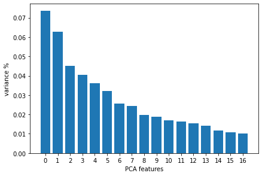

```python
import pandas as pd
import numpy as np
import matplotlib.pyplot as plt
from sklearn.cluster import KMeans
from sklearn.decomposition import PCA
from sklearn.preprocessing import StandardScaler
from sklearn.preprocessing import OneHotEncoder

# Loading the csv file data
df = pd.read_csv('homework_2.csv')

#Formatting dataframe splitting by ';'
formattedDF = pd.DataFrame(columns=['age','job','marital','education','default','balance','housing','loan','contact','day','month','duration','campaign','pdays','previous','poutcome','y'])
formattedDF[['age','job','marital','education','default','balance','housing','loan','contact','day','month','duration','campaign','pdays','previous','poutcome','y']] = df['age;"job";"marital";"education";"default";"balance";"housing";"loan";"contact";"day";"month";"duration";"campaign";"pdays";"previous";"poutcome";"y"'].str.split(';', expand=True)

# Data Preprocessing
ohe = OneHotEncoder(sparse=False)
formattedDF_transformed = ohe.fit_transform(formattedDF)

# Creating PCA instance: pca
pca = PCA(n_components=17) # for 17 columns
principalComponents = pca.fit_transform(formattedDF_transformed)

print("Eigen vector values::")
print(pca.components_)

print("\n Variance in each dimension::")
print(pca.explained_variance_)

#Plot explained variances
features = range(pca.n_components_)
plt.bar(range(len(pca.explained_variance_ratio_)), pca.explained_variance_ratio_)
plt.tight_layout()
plt.xlabel('PCA features')
plt.ylabel('variance %')
plt.xticks(features)

# Save components to a DataFrame
PCA_components = pd.DataFrame(principalComponents)
```

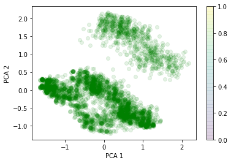

```python
plt.scatter(PCA_components[0], PCA_components[1], alpha=.1, color='green')
plt.xlabel('PCA 1')
plt.ylabel('PCA 2')
plt.colorbar()
```

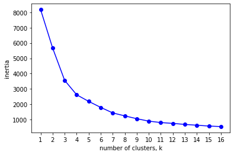

```python
ks = range(1, 17)
inertias = []
for k in ks:
    # Create a KMeans instance with k clusters: model
    model = KMeans(n_clusters=k)

    # Fit model to samples
    model.fit(PCA_components.iloc[:,:3])

    # Append the inertia to the list of inertias
    inertias.append(model.inertia_)

plt.plot(ks, inertias, '-o', color='blue')
plt.xlabel('number of clusters, k')
plt.ylabel('inertia')
plt.xticks(ks)
plt.show()
```

The above plot shows a slow decrease in intertia after 3 clusters i.e after k=3. The value of the inertia is no longer significant after 3rd cluster, neither is the variance of the rest of the data after the elbow point. Hence, everything after k=3 can be discarded for further analysis.